# Predicting Probability of Hailstorms Using Time Series Forecasting

Jessica Manko  
GEOG5990 Final Project  
University of Colorado Denver  
Spring 2020

## Introduction

Severe weather is a meteorological phenomena with the potential to cause damage. Types of severe weather phenomena vary based on the latitude, altitude, topography, seasonal, and atmospheric conditions. Hail is a form of precipitation consisting of solid ice that forms inside thunderstorm updrafts. Hail is possible within most thunderstorms depending on conditions. Hail can cause billions of dollars of damage to structures, crops and livestock. There are patterns associated with when and where hailstorms tend to occur based on time of day and season in the year. It is useful to accurately forecast when these events will occur to relay warnings and prepare to minimize damages.

The National Oceanic and Atmospheric Administration's (NOAA) Severe Weather Data Inventory (SWDI) is an integrated database of severe weather records for the United States (US). The National Weather Service (NWS) Doppler (NEXRAD) radar system estimates the intensity, position, velocity, and type of moisture in the atmosphere. Each radar site includes equipment and software that searches this basic precipitation data for patterns that estimate the presence of various kinds of severe weather events.

The dataset used for this project is a product of the NEXRAD radar system and consists of time series data of probability of hail, probability of severe hail, and maximum size of hail for different locations in the US.

Time series is a collection of data points collected at constant time intervals. The time dimension adds an explicit order dependence between observations. Most time series exhibit seasonality trends, particularly within weather. Time series forecasting can be applied to analyze long term trends and predict future events. In this analysis, the ARIMA and Prophet models are used to forecast probability of hail.

## Data Exploration

This data is a product of NOAA's National Centers for Environmental Information (NCEI). This dataset covers hail detections from 2015. This includes the probability of a weather event as well as the size and severity of hail. This helps understand potential damage to property and injury to people. Records are event-level records. Individual storm cells with a high probability of yielding hail are included in this dataset: a total of 1,048,575 rows with 10 columns.  
Columns consist of: Time, Lon, Lat, WSR_ID, CELL_ID, Range, Azimuth, Probability, Severe Probability, and Max Size. According to NOAA, these are the definitions of the columns:  
WSR_ID - "NEXRAD or TDWR SITE ID"  
CELL_ID - "CELL ID UNIQUE TO RADAR SITE"  
PROB - "PROBABILITY OF HAIL [PERCENT]"  
SEVPROB - "PROB. OF SEVERE HAIL [PERCENT]"  
MAXSIZE - "MAX SIZE [IN]"

## Goal

The goal of this project is to run a time series prediction on the probability of hail events occurring using the Prophet and ARIMA models.

## Data Preprocessing

This is a large dataset with 1,048,575 records, so I decided to subset the first 20,000 to reduce model runtime and memory issues. I looked at the data properties and cleaned up the data by removing null values and dropping duplicates. I ran some descriptive statistics to better understand the data. I then created a datetime index to run the time series prediction and subset the data frame to the columns I needed to run analysis. I chose to trim some sparse data away and focus on events after 01-03-2015. I subset the datetime index to create a column for hour for future analysis.

```python
import pandas as pd
import numpy as np
import matplotlib.pyplot as plt
import seaborn as sns
from shapely.geometry import Point, box
import geopandas as gpd
from geopandas import GeoDataFrame, GeoSeries
from statsmodels.tsa.arima_model import ARIMA
import fbprophet

df = pd.read_csv('hail-2015.csv')
```

```
Importing plotly failed. Interactive plots will not work.
```

```python
df.shape
```

```
(1048575, 10)
```

```python
#Subset first 20000 values of dataset since it is so large
df = df[:20000]
```

```python
#Overview of original data
#Columns within dataset
print(df.columns)
#Data properties
print(df.dtypes)
#Number of features
print(len(df.columns))
#Number of observations
print(len(df))
df.head
df.shape
```

```
Index(['X.ZTIME', 'LON', 'LAT', 'WSR_ID', 'CELL_ID', 'RANGE', 'AZIMUTH',
       'SEVPROB', 'PROB', 'MAXSIZE'],
      dtype='object')
X.ZTIME    float64
LON        float64
LAT        float64
WSR_ID      object
CELL_ID     object
RANGE        int64
AZIMUTH      int64
SEVPROB      int64
PROB         int64
MAXSIZE    float64
dtype: object
10
20000
```

```
(20000, 10)
```

```python
# Clean up data; remove null values
# Get values of indexes for which values are null
null_values = df[ df['PROB'] == -999 ].index

# Delete these row indexes from dataFrame
df.drop(null_values , inplace=True)
# Now we have removed null values from data
print(len(df))
```

```
15346
```

```python
#Create datetime index
df['X.ZTIME'] = pd.to_datetime(df['X.ZTIME'], format='%Y%m%d%H%M%S')
df = df.groupby('X.ZTIME').mean().reset_index()
df.index = pd.DatetimeIndex(df['X.ZTIME'])

# sparse time series
# subset columns used in this analysis
df = pd.DataFrame(df[["PROB","LAT","LON", "MAXSIZE"]])
```

```python
#Create hour and date columns for further analysis
df['HOUR'] = df.index.hour
df['DATE'] = df.index

#Drop duplicates
df.drop_duplicates()
```

| X.ZTIME | PROB | LAT | LON | MAXSIZE | HOUR | DATE |
| --- | --- | --- | --- | --- | --- | --- |
| 2015-01-01 05:07:06 | 10.000000 | 32.663080 | -97.160030 | 0.50 | 5 | 2015-01-01 05:07:06 |
| 2015-01-01 05:21:18 | 50.000000 | 32.577960 | -97.018490 | 0.50 | 5 | 2015-01-01 05:21:18 |
| 2015-01-01 05:21:56 | 20.000000 | 32.588100 | -97.017350 | 0.50 | 5 | 2015-01-01 05:21:56 |
| 2015-01-01 05:24:09 | 40.000000 | 32.592870 | -96.995530 | 0.50 | 5 | 2015-01-01 05:24:09 |
| 2015-01-01 05:30:08 | 30.000000 | 32.625500 | -96.961800 | 0.50 | 5 | 2015-01-01 05:30:08 |
| 2015-01-01 05:31:02 | 10.000000 | 32.631140 | -96.935910 | 0.50 | 5 | 2015-01-01 05:31:02 |
| 2015-01-01 05:57:50 | 10.000000 | 32.931830 | -97.715100 | 0.50 | 5 | 2015-01-01 05:57:50 |
| 2015-01-01 06:03:15 | 30.000000 | 32.145440 | -97.064450 | 0.50 | 6 | 2015-01-01 06:03:15 |
| 2015-01-01 06:06:06 | 30.000000 | 32.144140 | -97.048420 | 0.50 | 6 | 2015-01-01 06:06:06 |
| 2015-01-01 06:09:15 | 10.000000 | 32.175030 | -96.998840 | 0.50 | 6 | 2015-01-01 06:09:15 |
| 2015-01-01 06:09:22 | 30.000000 | 27.872270 | -101.380120 | 0.50 | 6 | 2015-01-01 06:09:22 |
| 2015-01-01 06:12:06 | 10.000000 | 32.175600 | -97.014250 | 0.50 | 6 | 2015-01-01 06:12:06 |
| 2015-01-01 06:22:15 | 50.000000 | 27.939280 | -101.290090 | 0.50 | 6 | 2015-01-01 06:22:15 |
| 2015-01-01 06:25:44 | 80.000000 | 27.952210 | -101.243420 | 0.50 | 6 | 2015-01-01 06:25:44 |
| 2015-01-01 06:28:57 | 80.000000 | 27.980390 | -101.223180 | 0.50 | 6 | 2015-01-01 06:28:57 |
| 2015-01-01 06:36:52 | 40.000000 | 32.397200 | -96.931740 | 0.50 | 6 | 2015-01-01 06:36:52 |
| 2015-01-01 06:39:44 | 40.000000 | 32.413890 | -96.904600 | 0.50 | 6 | 2015-01-01 06:39:44 |
| 2015-01-01 06:42:51 | 40.000000 | 32.417340 | -96.837730 | 0.50 | 6 | 2015-01-01 06:42:51 |
| 2015-01-01 06:43:18 | 35.000000 | 28.161385 | -101.167500 | 0.50 | 6 | 2015-01-01 06:43:18 |
| 2015-01-01 06:45:43 | 40.000000 | 33.073970 | -97.691530 | 0.50 | 6 | 2015-01-01 06:45:43 |
| 2015-01-01 06:47:00 | 35.000000 | 28.067285 | -101.361665 | 0.50 | 6 | 2015-01-01 06:47:00 |
| 2015-01-01 06:51:12 | 65.000000 | 28.087570 | -101.327450 | 0.50 | 6 | 2015-01-01 06:51:12 |
| 2015-01-01 06:55:08 | 55.000000 | 28.115220 | -101.306585 | 0.50 | 6 | 2015-01-01 06:55:08 |
| 2015-01-01 06:59:21 | 10.000000 | 28.142250 | -101.266745 | 0.50 | 6 | 2015-01-01 06:59:21 |
| 2015-01-01 07:03:18 | 80.000000 | 28.149600 | -101.498040 | 0.50 | 7 | 2015-01-01 07:03:18 |
| 2015-01-01 07:07:15 | 80.000000 | 28.155810 | -101.450190 | 0.50 | 7 | 2015-01-01 07:07:15 |
| 2015-01-01 07:33:39 | 50.000000 | 28.398680 | -100.945800 | 0.50 | 7 | 2015-01-01 07:33:39 |
| 2015-01-01 07:39:11 | 50.000000 | 28.484040 | -100.951610 | 0.50 | 7 | 2015-01-01 07:39:11 |
| 2015-01-01 07:56:29 | 20.000000 | 28.609570 | -100.825430 | 0.50 | 7 | 2015-01-01 07:56:29 |
| 2015-01-01 08:31:05 | 30.000000 | 28.873010 | -100.248210 | 0.50 | 8 | 2015-01-01 08:31:05 |
| ... | ... | ... | ... | ... | ... | ... |
| 2015-01-04 13:14:18 | 46.666667 | 32.298460 | -84.933637 | 0.50 | 13 | 2015-01-04 13:14:18 |
| 2015-01-04 13:15:42 | 35.000000 | 32.999870 | -83.834180 | 0.50 | 13 | 2015-01-04 13:15:42 |
| 2015-01-04 13:16:03 | 10.000000 | 34.140120 | -84.170750 | 0.50 | 13 | 2015-01-04 13:16:03 |
| 2015-01-04 13:16:34 | 66.000000 | 29.750190 | -86.384868 | 0.55 | 13 | 2015-01-04 13:16:34 |
| 2015-01-04 13:16:43 | 37.500000 | 30.267500 | -86.009433 | 0.50 | 13 | 2015-01-04 13:16:43 |
| 2015-01-04 13:17:19 | 25.000000 | 29.801327 | -86.275445 | 0.50 | 13 | 2015-01-04 13:17:19 |
| 2015-01-04 13:17:43 | 50.000000 | 32.020030 | -85.001273 | 0.50 | 13 | 2015-01-04 13:17:43 |
| 2015-01-04 13:18:01 | 30.000000 | 31.748920 | -84.873435 | 0.50 | 13 | 2015-01-04 13:18:01 |
| 2015-01-04 13:18:55 | 55.000000 | 30.072540 | -86.121655 | 0.50 | 13 | 2015-01-04 13:18:55 |
| 2015-01-04 13:20:00 | 20.000000 | 34.011510 | -82.821190 | 0.50 | 13 | 2015-01-04 13:20:00 |
| 2015-01-04 13:20:14 | 60.000000 | 30.903930 | -85.384990 | 0.75 | 13 | 2015-01-04 13:20:14 |
| 2015-01-04 13:21:02 | 60.000000 | 33.957900 | -82.850470 | 0.50 | 13 | 2015-01-04 13:21:02 |
| 2015-01-04 13:21:08 | 33.333333 | 30.359337 | -85.860557 | 0.50 | 13 | 2015-01-04 13:21:08 |
| 2015-01-04 13:21:21 | 65.000000 | 32.347575 | -84.744510 | 0.50 | 13 | 2015-01-04 13:21:21 |
| 2015-01-04 13:21:34 | 45.714286 | 29.508534 | -86.652884 | 0.50 | 13 | 2015-01-04 13:21:34 |
| 2015-01-04 13:22:13 | 25.000000 | 29.962425 | -86.161355 | 0.50 | 13 | 2015-01-04 13:22:13 |
| 2015-01-04 13:23:04 | 63.333333 | 30.853457 | -85.474670 | 0.50 | 13 | 2015-01-04 13:23:04 |
| 2015-01-04 13:23:47 | 10.000000 | 34.010310 | -82.781110 | 0.50 | 13 | 2015-01-04 13:23:47 |
| 2015-01-04 13:23:57 | 20.000000 | 36.404360 | -75.977670 | 0.50 | 13 | 2015-01-04 13:23:57 |
| 2015-01-04 13:24:23 | 35.000000 | 30.571325 | -85.687933 | 0.50 | 13 | 2015-01-04 13:24:23 |
| 2015-01-04 13:24:32 | 10.000000 | 33.999960 | -82.802830 | 0.50 | 13 | 2015-01-04 13:24:32 |
| 2015-01-04 13:24:45 | 50.000000 | 32.489427 | -84.862290 | 0.50 | 13 | 2015-01-04 13:24:45 |
| 2015-01-04 13:24:55 | 30.000000 | 31.212590 | -85.260960 | 0.50 | 13 | 2015-01-04 13:24:55 |
| 2015-01-04 13:25:10 | 20.000000 | 33.959490 | -82.784010 | 0.50 | 13 | 2015-01-04 13:25:10 |
| 2015-01-04 13:25:45 | 53.333333 | 29.901193 | -86.204117 | 0.50 | 13 | 2015-01-04 13:25:45 |
| 2015-01-04 13:25:50 | 20.000000 | 28.485820 | -88.850150 | 0.50 | 13 | 2015-01-04 13:25:50 |
| 2015-01-04 13:26:16 | 50.000000 | 34.015590 | -82.770710 | 0.50 | 13 | 2015-01-04 13:26:16 |
| 2015-01-04 13:26:35 | 67.500000 | 29.409058 | -86.523435 | 0.50 | 13 | 2015-01-04 13:26:35 |
| 2015-01-04 13:27:09 | 30.000000 | 29.845050 | -86.198020 | 0.50 | 13 | 2015-01-04 13:27:09 |
| 2015-01-04 13:28:07 | 42.500000 | 31.056615 | -85.343682 | 0.50 | 13 | 2015-01-04 13:28:07 |

4855 rows × 6 columns

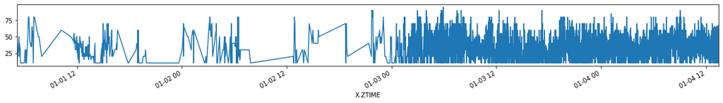

```python
#Create plot for probability of hail over time
df['PROB'].plot(kind='line', figsize =(20,2))
```

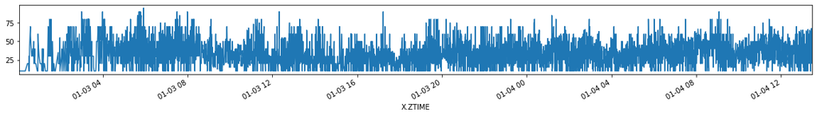

```python
#trim sparse data away.
#I chose to focus on events after 01-03
df = df[df.index > pd.to_datetime("20150103000000", format='%Y%m%d%H%M%S')]
df['PROB'].plot(kind='line', figsize =(20,2))
```

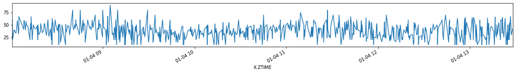

```python
# zoom in to see noise
df_sub = df[df.index > pd.to_datetime("20150104080000", format='%Y%m%d%H%M%S')]
#plot between probability and time
df_sub['PROB'].plot(kind='line', figsize =(20,2))
```

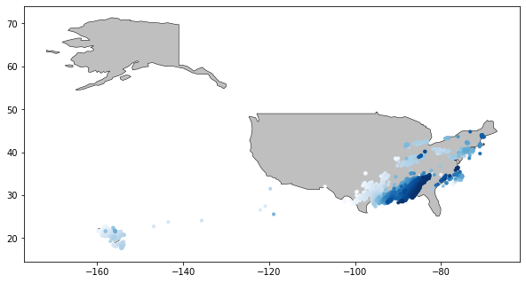

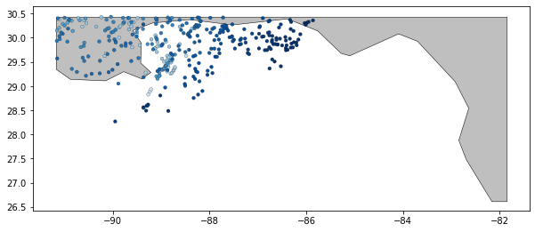

```python
# another attempt to cut down noise - by subsetting to location
# I didn't end up running analysis on location but it was interesting to see where events occurred
geometry = [Point(xy) for xy in zip(df['LON'], df['LAT'])]
gdf = GeoDataFrame(df, geometry=geometry)

#this is a simple map that goes with geopandas
#darker dots represent higher probability of hail
world = gpd.read_file(gpd.datasets.get_path('naturalearth_lowres'))
usa = world[world["name"].str.contains("United States")]
# bbox = GeoSeries(box(-91.173340, 26.617997, -81.856933, 30.433519))

gdf.plot(ax=usa.plot(figsize=(10, 6), edgecolor="black", facecolor="0.75",  linewidth=.5), marker='o', markersize=15, c="PROB", colormap='Blues',  linewidth=.2);

#create a bounding box to zoom into an area with hail
region = usa.geometry.unary_union.intersection(box(-91.173340, 26.617997, -81.856933, 30.433519))
region = GeoSeries(region)
gdf["geometry"] = gdf.geometry.intersection(box(-91.173340, 26.617997, -81.856933, 30.433519))


gdf.plot(ax=region.plot(figsize=(10, 6), edgecolor="black", facecolor="0.75", linewidth=.5), marker='o', markersize=15, c="PROB", colormap='Blues', edgecolor="black", linewidth=.2);
```

```python
#Descriptive Statistics
print(df.describe())
```

```
              PROB          LAT          LON      MAXSIZE         HOUR
count  4528.000000  4528.000000  4528.000000  4528.000000  4528.000000
mean     33.534840    31.368508   -94.388144     0.504154    10.160998
std      16.208723     4.710652    20.180198     0.020997     6.514527
min      10.000000    17.644975  -159.800610     0.500000     0.000000
25%      20.000000    29.754503   -94.484952     0.500000     5.000000
50%      30.000000    31.278183   -88.706000     0.500000     9.000000
75%      43.333333    33.099480   -86.212796     0.500000    15.000000
max      95.000000    44.791510   -69.945970     0.750000    23.000000
```

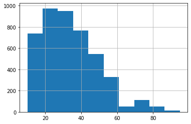

```python
#Visualize distribution of probability
df.PROB.hist()
```

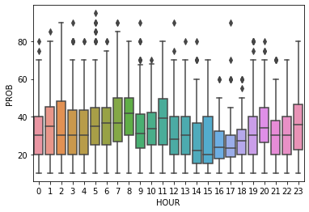

```python
#observe range of probability over hours for future work
sns.boxplot(data=df, x='HOUR', y='PROB')
```

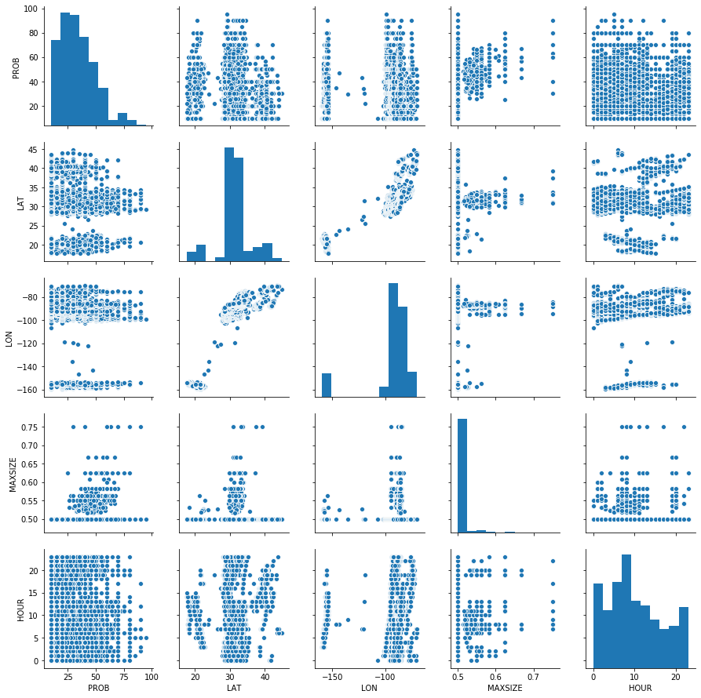

```python
#plot piecewise functions of variables
plots = sns.pairplot(df)
```

## Predicting Based on Seconds

### ARIMA Model

One of the most common methods used in time series forecasting is known as the ARIMA model, which stands for AutoregRessive Integrated Moving Average. ARIMA is a model that can be fitted to time series data in order to better understand or predict future points in the series. Parameters include:  
p: The number of lag observations included in the model, or lag order.  
d: The number of times that the raw observations or degree of differencing.  
q: The size of the moving average window, or order of moving average.

```
                             ARIMA Model Results
==============================================================================
Dep. Variable:                 D.PROB   No. Observations:                 3831
Model:                 ARIMA(4, 1, 7)   Log Likelihood              -16009.121
Method:                       css-mle   S.D. of innovations             15.788
Date:                Thu, 14 May 2020   AIC                          32044.242
Time:                        11:43:51   BIC                          32125.503
Sample:                             1   HQIC                         32073.110

================================================================================
                   coef    std err          z      P>|z|      [0.025      0.975]
--------------------------------------------------------------------------------
const            0.0022      0.010      0.212      0.832      -0.018       0.023
ar.L1.D.PROB    -0.8833      0.451     -1.957      0.050      -1.768       0.002
ar.L2.D.PROB    -1.2518      0.379     -3.305      0.001      -1.994      -0.509
ar.L3.D.PROB    -0.8006      0.472     -1.696      0.090      -1.726       0.125
ar.L4.D.PROB    -0.1793      0.348     -0.516      0.606      -0.860       0.502
ma.L1.D.PROB    -0.0941      0.451     -0.209      0.835      -0.978       0.790
ma.L2.D.PROB     0.3960      0.315      1.256      0.209      -0.222       1.014
ma.L3.D.PROB    -0.4349      0.316     -1.377      0.168      -1.054       0.184
ma.L4.D.PROB    -0.5999      0.336     -1.787      0.074      -1.258       0.058
ma.L5.D.PROB    -0.1448      0.336     -0.431      0.666      -0.803       0.513
ma.L6.D.PROB     0.0060      0.018      0.341      0.733      -0.029       0.041
ma.L7.D.PROB     0.0379      0.017      2.258      0.024       0.005       0.071
                                    Roots
=============================================================================
                  Real          Imaginary           Modulus         Frequency
-----------------------------------------------------------------------------
AR.1           -0.0485           -1.0010j            1.0021           -0.2577
AR.2           -0.0485           +1.0010j            1.0021            0.2577
AR.3           -2.1846           -0.8844j            2.3568           -0.4388
AR.4           -2.1846           +0.8844j            2.3568            0.4388
MA.1            1.0454           -0.0000j            1.0454           -0.0000
MA.2           -0.0499           -0.9990j            1.0002           -0.2579
MA.3           -0.0499           +0.9990j            1.0002            0.2579
MA.4            3.0514           -0.0000j            3.0514           -0.0000
MA.5           -1.7117           -0.0000j            1.7117           -0.5000
MA.6           -1.2223           -1.8258j            2.1972           -0.3439
MA.7           -1.2223           +1.8258j            2.1972            0.3439
-----------------------------------------------------------------------------
15.17028376781859
```

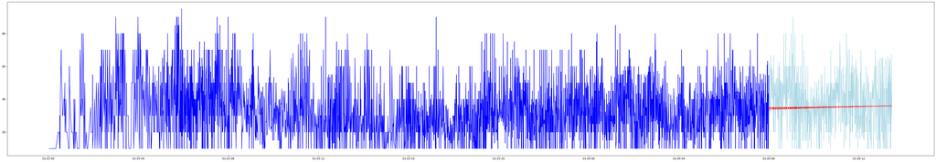

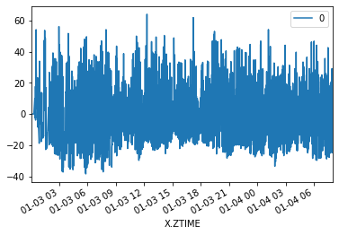

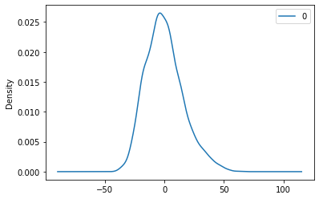

```
                 0
count  3831.000000
mean      0.042321
std      15.799244
min     -38.455877
25%     -11.320886
50%      -1.346368
75%       9.460577
max      64.011254
```

```python
#separate training data before 01-04 and test data after 01-04
train = df.loc[ : '2015-01-04 08:00:00']
test = df.loc['2015-01-04 08:00:00': ]

# ARIMA
model = ARIMA(train["PROB"], order=(4,1,7))
model_fit = model.fit(disp=0)
print(model_fit.summary())
predictions = pd.DataFrame(model_fit.forecast(len(test))[0])
predictions.index = test.index

#calculate rmse
rmse = np.sqrt(((predictions[0] - test['PROB'])**2).mean())
print(rmse)

#plot
ax = plt.axes([0, 0, 8, 2])
ax.plot(train["PROB"], color='blue')
ax.plot(test["PROB"], color='lightblue')
ax.plot(predictions, color='red', linewidth=1)

# plot residual errors
residuals = pd.DataFrame(model_fit.resid)
residuals.plot()
plt.show()
residuals.plot(kind='kde')
plt.show()
print(residuals.describe())
```

### Prophet Model

Prophet is a procedure created by Facebook for forecasting time series data based on an additive model where non-linear trends are fit with yearly, weekly, and daily seasonality. Prophet is an additive model incorporating trend, seasonality, effects of holidays or large events, and error. In this scenario, trend is most representative of the data and seasonality would be useful for longer-term data.

```
15.331923900650928
```

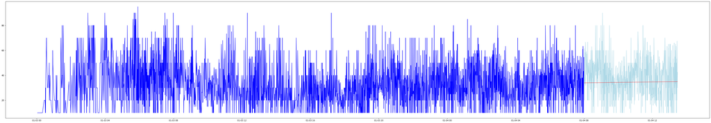

```python
# Run fbprophet for prediction
# Prophet requires columns ds (Date) and y (probability)
train['ds'], train['y'] = train['DATE'],  train['PROB']
test['ds'], test['y'] = test['DATE'],  test['PROB']

# Make the prophet model and fit on the data
model2 = fbprophet.Prophet(changepoint_prior_scale=0.15)
model2_fit = model2.fit(train)

# Make predictions
predictions2 = model2.predict(test)['yhat']
predictions2.index = test.index

#calculate rmse
rmse = np.sqrt(((predictions2[0] - test['PROB'])**2).mean())
print(rmse)

#plot
ax2 = plt.axes([0, 0, 8, 2])
ax2.plot(train["PROB"], color='blue')
ax2.plot(test["PROB"], color='lightblue')
ax2.plot(predictions2, color='red', linewidth=1)
```

## Predicting Based on Minutes

```python
# test on coarser time resolution of minute
# resample data and group by minute
by_minute = df.index.year.astype(str).str.cat([x.astype(str).str.zfill(2) for x in [ df.index.month, df.index.day, df.index.hour,df.index.minute ]])
df["by_minute"] = pd.to_datetime(by_minute, format="%Y%m%d%H%M")
df = df.groupby("by_minute").mean()
```

```
                             ARIMA Model Results
==============================================================================
Dep. Variable:                 D.PROB   No. Observations:                  270
Model:                 ARIMA(2, 1, 2)   Log Likelihood                -996.936
Method:                       css-mle   S.D. of innovations              9.611
Date:                Thu, 14 May 2020   AIC                           2005.873
Time:                        11:44:01   BIC                           2027.463
Sample:                             1   HQIC                          2014.543

================================================================================
                   coef    std err          z      P>|z|      [0.025      0.975]
--------------------------------------------------------------------------------
const            0.0282      0.007      3.827      0.000       0.014       0.043
ar.L1.D.PROB    -0.6522      0.237     -2.749      0.006      -1.117      -0.187
ar.L2.D.PROB    -0.0574      0.067     -0.853      0.394      -0.189       0.074
ma.L1.D.PROB    -0.3115      0.232     -1.343      0.181      -0.766       0.143
ma.L2.D.PROB    -0.6884      0.232     -2.970      0.003      -1.143      -0.234
                                    Roots
=============================================================================
                  Real          Imaginary           Modulus         Frequency
-----------------------------------------------------------------------------
AR.1           -1.8267           +0.0000j            1.8267            0.5000
AR.2           -9.5442           +0.0000j            9.5442            0.5000
MA.1            1.0000           +0.0000j            1.0000            0.0000
MA.2           -1.4526           +0.0000j            1.4526            0.5000
-----------------------------------------------------------------------------
11.613207564661991
```

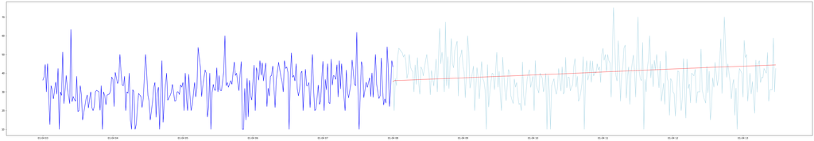

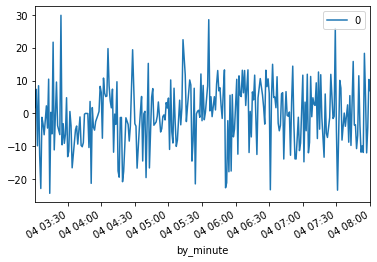

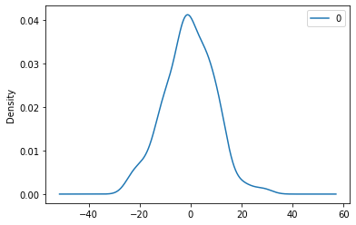

```
                0
count  270.000000
mean    -0.567323
std      9.711728
min    -24.322356
25%     -6.664964
50%     -0.844961
75%      5.965422
max     29.856372
```

```python
#running models by minute
#separate training data before 01-04 and test data after 01-04
train = df.loc['2015-01-04 03:00:00' : '2015-01-04 08:00:00']
test = df.loc['2015-01-04 08:00:00': ]

# ARIMA
# I had the change parameters to run this coarser time scale
model = ARIMA(train["PROB"], order=(2,1,2))
model_fit = model.fit(disp=0)
print(model_fit.summary())
predictions = pd.DataFrame(model_fit.forecast(len(test))[0])
predictions.index = test.index

#calculate rmse
rmse = np.sqrt(((predictions[0] - test['PROB'])**2).mean())
print(rmse)

#plot
ax = plt.axes([0, 0, 8, 2])
ax.plot(train["PROB"], color='blue')
ax.plot(test["PROB"], color='lightblue')
ax.plot(predictions, color='red', linewidth=1)

# plot residual errors
residuals = pd.DataFrame(model_fit.resid)
residuals.plot()
plt.show()
residuals.plot(kind='kde')
plt.show()
print(residuals.describe())
```

```
10.876890267784368
```

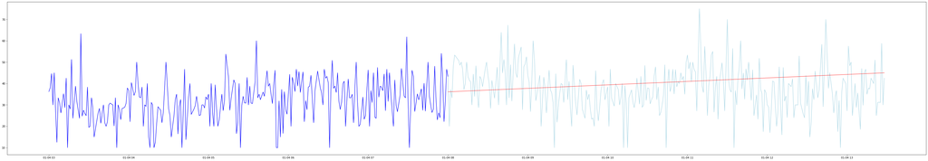

```python
# Run fbprophet for prediction
# Prophet requires columns ds (Date) and y (probability)

#create new column for minute data to convert
df['MINUTE'] = df.index
#change names of columns for training and test data
train['ds'], train['y'] = df['MINUTE'],  train['PROB']
test['ds'], test['y'] = df['MINUTE'],  test['PROB']

# Make the prophet model and fit on the data
model2 = fbprophet.Prophet(changepoint_prior_scale=0.15)
model2_fit = model2.fit(train)

# Make predictions
predictions2 = model2.predict(test)['yhat']
predictions2.index = test.index

#calculate rmse
rmse = np.sqrt(((predictions2[0] - test['PROB'])**2).mean())
print(rmse)

#plot
ax2 = plt.axes([0, 0, 8, 2])
ax2.plot(train["PROB"], color='blue')
ax2.plot(test["PROB"], color='lightblue')
ax2.plot(predictions2, color='red', linewidth=1)
```

## Results

The results of the models running based on seconds did not accurately represent future probability of hail. In the graphs above, the dark blue area represents training data, light blue area represents test data, and the red line represents the predicted time series. The prediction line is similar for both the ARIMA and Prophet models. This prediction line is not much better than drawing a line at the mean

The Root Mean Square Error (RMSE) was used to evaluate how accurately the models predicted the response. RMSE is the square root of the variance of the residuals indicating how close the observed data points are to the model’s predicted values. The ARIMA model had a RMSE of 15.17 and Prophet had a RMSE of 15.33. While lower values of RMSE indicate better fit, these two values are nearly identical so the models performed with similar accuracy.

The mean probability of hail was 33.5%, the standard deviation was 16.2%, and the range was 10%-95%. According to the RMSE, there was approximately a 15% error for both models. Compared to the standard deviation of 16.2%, errors of the models are only ~0.8% better than the error of a horizontal line at the mean.

Resampling the data to a coarser time scale of minutes and reducing the training data time frame produced slightly more accurate results. The RMSE of ARIMA was 11.61% and RMSE of Prophet was 10.88%.

Throughout the analysis process, I adjusted the parameters of the models to experiment with different prediction outcomes. Zooming into a smaller prediction period was important because the data had such a fine resolution of seconds. Resampling the data to a coarser time scale of minutes and shortening the training period yielded more accurate results. Running the models on shorter time frames and continuing to resample to a coarser time scale of hours or days would forecast more accurate probability further out into the future.

## Conclusion

The goal of the analysis was to run a time series prediction on the probability of hail events occurring using the Prophet and ARIMA models. This project created a framework to preprocess, visualize, and apply a machine learning model for prediction on time series data. Key insights gained included the workflow of running time series prediction and understanding the algorithms within the models.

Limitations within the data include possible spatial inaccuracies with NEXRAD Radar as it decreases with range from Radar sites. Within the analysis, limitations include total spatial consolidation where the model was averaging hail probability for the entire US. The data available was only for January-April and time stamps for records were by the second. The subset I created was only for a couple of days in January to reduce memory.

Recommendations include smoothing out the prediction and resampling the data to a coarser time resolution of hours or days. In addition, it would be interesting to observe how changing the training and test date periods and adjusting the parameters of the models would affect the results. In the future, I would reduce the training data and test data time periods to run the prediction models. These methods could be duplicated to perform time series forecasting on different datasets for future work.

## References

Brownlee, Jason. “How to Create an ARIMA Model for Time Series Forecasting in Python.” Machine Learning Mastery, 3 May 2020, machinelearningmastery.com/arima-for-time-series-forecasting-with-python/.  
Brownlee, Jason. “What Is Time Series Forecasting?” Machine Learning Mastery, 21 Aug. 2019, machinelearningmastery.com/time-series-forecasting/.  
“Hail Basics.” NOAA National Severe Storms Laboratory, www.nssl.noaa.gov/education/svrwx101/hail/.  
NOAA. “Severe Weather Data Inventory.” Kaggle, 24 Oct. 2016, www.kaggle.com/noaa/severe-weather-data-inventory. NOAA's Severe Weather Data Inventory, www.ncdc.noaa.gov/swdi/.  
Lyla, Yang. “A Quick Start of Time Series Forecasting with a Practical Example Using FB Prophet.” Medium, Towards Data Science, 10 Jan. 2019, towardsdatascience.com/a-quick-start-of-time-series-forecasting-with-a-practical-example-using-fb-prophet-31c4447a2274.

## Github

https://github.com/jmanko/bigdata